# Supporting Information

Ryo et al. (2019) Machine learning with the hierarchy-of-hypotheses (HoH) approach discovers novel pattern in studies on biological invasions. Research Synthesis Methods

Document created on 2019 April 23

### Where is the dataset?

The data can be seen in this file, following to the documentation of the analysis section.  
The dataset in csv format may be available from the publication information at [Research Synthesis Methods](https://onlinelibrary.wiley.com/journal/17592887),  
or from the corresponding author, Masahiro Ryo masahiroryo@gmail.com

### Reading the dataset

The dataset name is **Supporting information_dataset.csv** Let’s read the dataset from the csv format and see the first 3 rows.

```r
data = data.frame(read.csv("Supporting information_dataset.csv"))
data = data[which(!is.na(data[,1])),1:ncol(data)]
head(data, 3)
```

```
##   Response Indicator                        Comparison     Enemies
## 1        S    infest Aliens in native vs. invad. range Specialists
## 2        Q    infest Aliens in native vs. invad. range        <NA>
## 3        S    infest Aliens in native vs. invad. range Specialists
##   Continent NElserth.America SElseuth.America EurElsepe Asia
## 1         2             N.Am             Else      Else Asia
## 2         3             N.Am             Else        EU Asia
## 3         2             Else             Else        EU Asia
##   Australia_Elseceania Africa   Ecosystem Focal.species Replicates
## 1                 Else   Else Terrestrial             1          2
## 2                 Else   Else Terrestrial             1          0
## 3                 Else   Else Terrestrial             1         21
##          Method Realism
## 1 observational   Field
## 2 observational   Field
## 3 observational   Field
```

We change the levels of column Response, from alphabetical order.

```r
data$Response = factor(data$Response, levels = c("S", "I", "Q"))
```

Note that the first column, Response, is the response variable (S: Supported, I: Inconsistent, Q: Questioned), and the others are used as explanatory variables.  
Detailed description for each variable is found in Material and Method section in the main text.

### Installing the package

We install and use the package [partykit](https://cran.r-project.org/web/packages/partykit/index.html)

```r
if(!"partykit" %in% rownames(installed.packages())) install.packages("partykit")
library("partykit")
```

### Modeling and visualization

```r
ctree.mdl = partykit::ctree(Response~., data=data,
              control = ctree_control(mincriterion =  0.95, testtype="Univariate"))
```

Note that each split is statistically tested (significance level of 0.05 as mincriterion = 1 - 0.05).  
The default setting uses Bonferroni correction of p-value, but we do not use it because of the relatively small sample size. We consider Type 2 error is more problematic than Type 1 error in this kind of exploratory study.

Let’s plot the built model structure

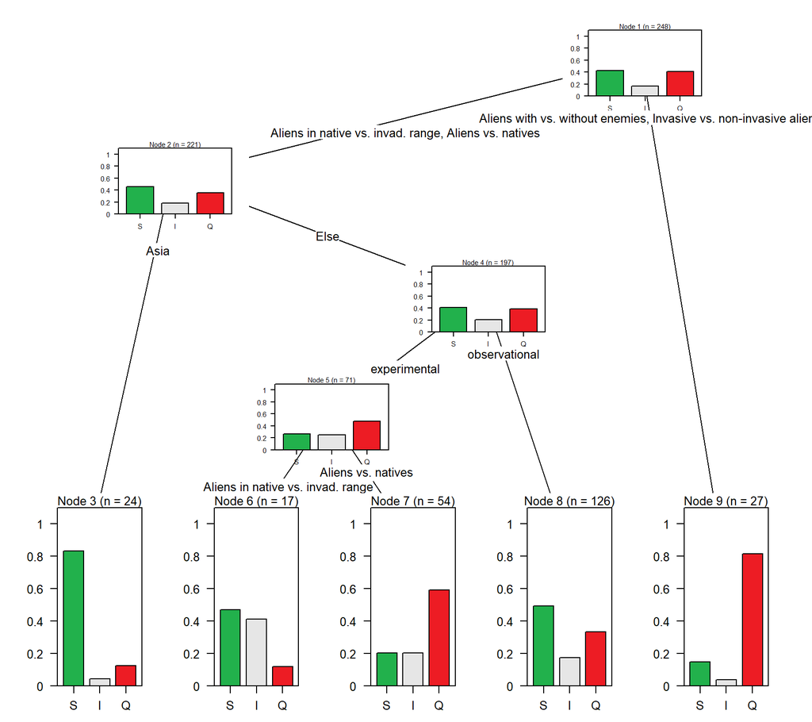

```r
plot(ctree.mdl, gp = gpar(cex= 0.8),
     inner_panel=node_barplot(ctree.mdl, fill=c("#22b14cff","#e6e6e6ff","#ed1c24ff"), gp = gpar(cex= 0.6)),
     terminal_panel=node_barplot(ctree.mdl, fill=c("#22b14cff","#e6e6e6ff","#ed1c24ff")),
     ep_args = c(just="increasing", justmin=1))
```

#### NOTE: Corresponding table?

Note that the positions and IDs of some nodes differ from the figure in the main text. In the main text, the figure was modified using [Inkscape software](https://inkscape.org/) for enhancing visualization, while the content itself does not change at all.

The corresponding table that compares the two figure nodes is as follows:

| This figure | In main text |
| --- | --- |
| Node 1 | Node 1 |
| Node 2 | Node 2 |
| Node 3 | Node 9 (highest S) |
| Node 4 | Node 3 |
| Node 5 | Node 4 |
| Node 6 | Node 7 |
| Node 7 | Node 6 |
| Node 8 | Node 8 |
| Node 9 | Node 5 (highest Q) |

#### NOTE: Plot function?

For a nicer visualization, the function above is complex with several parameters.  
Yet, the simplest version of the figure can be illustrated with just a single line as follows:

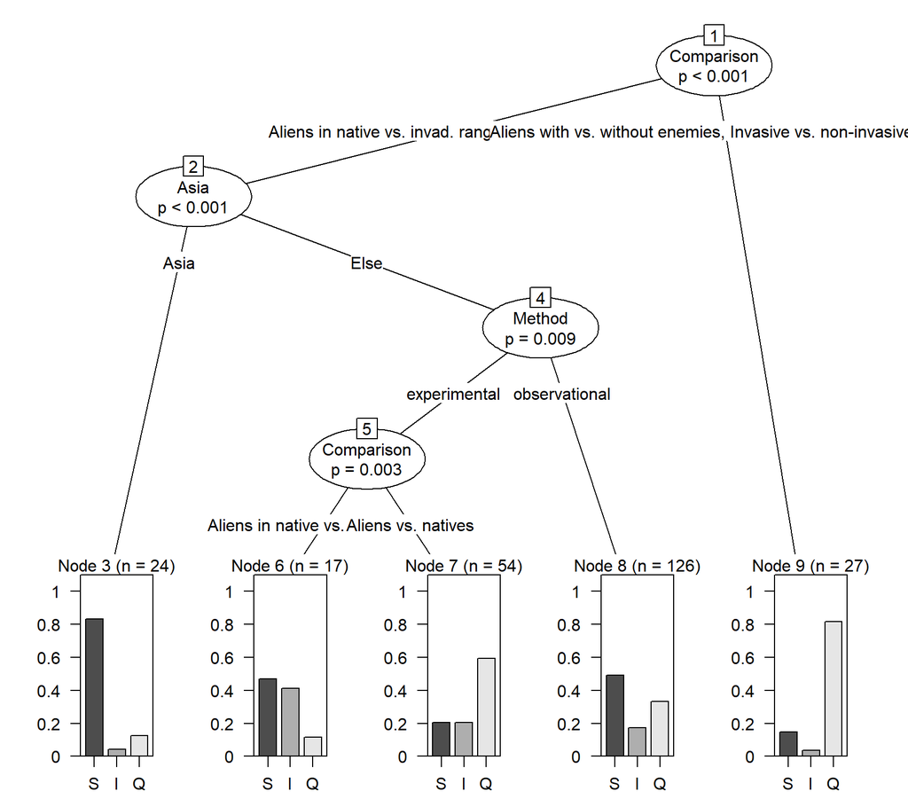

```r
plot(ctree.mdl)
```

ANOTHER VERSION:

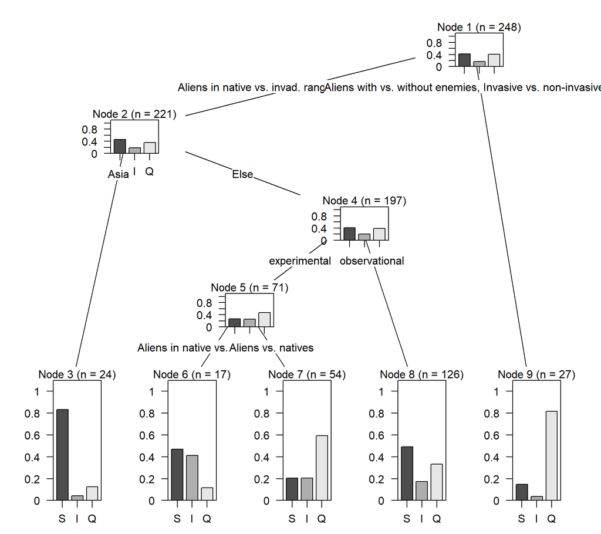

```r
plot(ctree.mdl, inner_panel=node_barplot)
```

## Dataset: Supporting information_dataset.csv

```r
data
```

[output not shown]

[output cut: 981 more lines]